# My First Time Series Forecasting Model

Şeyma Çakır

08. 05. 2021

# Introduction

In this report, **the Second Hand House Sales in Turkey** is analyzed. the Data using in the analysis consists of second hand house sales volume from January 2013 to 2021 March and the aim of this study construct a time series regression model to forecast next month’s (April 2021) sales.I construct my model step by step, and after get a basic times series regression model, some related ecomomic variables from [EVDS](https://evds2.tcmb.gov.tr/index.php?/evds/serieMarket) added to improve my model by analyzing correlation between second hand house sales in Turkey. In the end, the model results discussed and compared real value with predicted value.

# Data Manipulation and Visualization of Data

There is graph of second hand house sales over the years, histogram of second hand house sales, and boxplot of data year by year to get general idea about the data.

## Overview

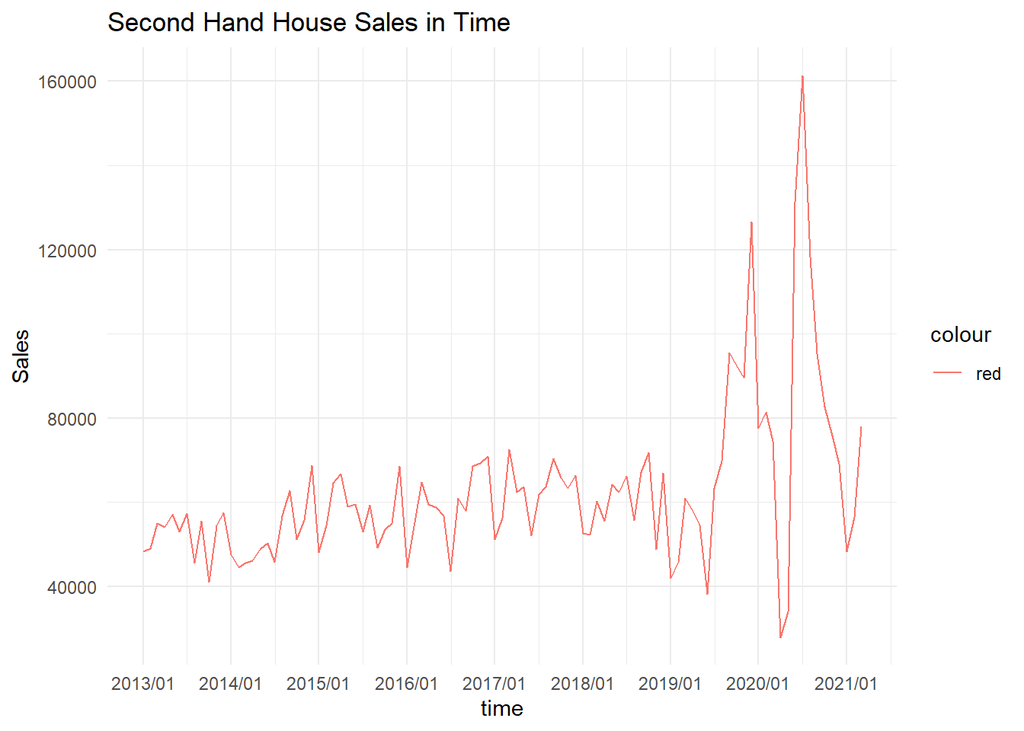

From the graph “Second Hand House Sales in Time”, It is obsreved that the variance of second hand house sales is increasing over the time, especially between 2019 and 2021.

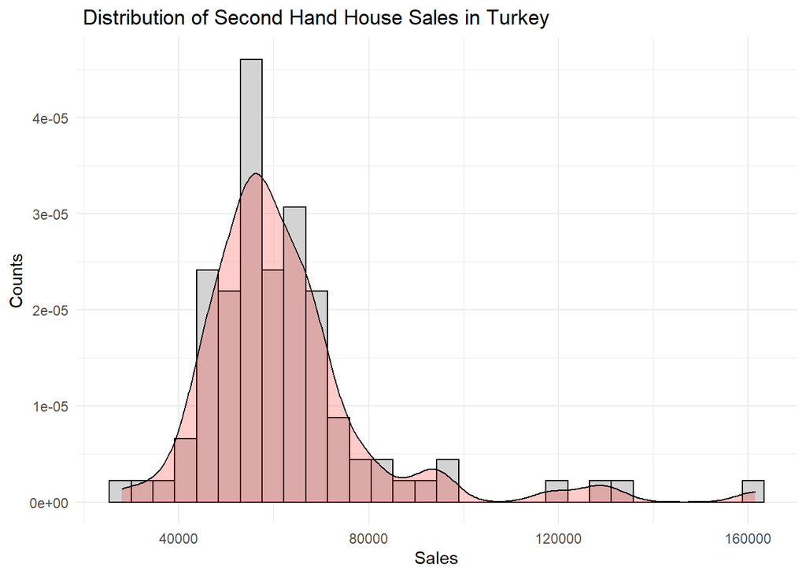

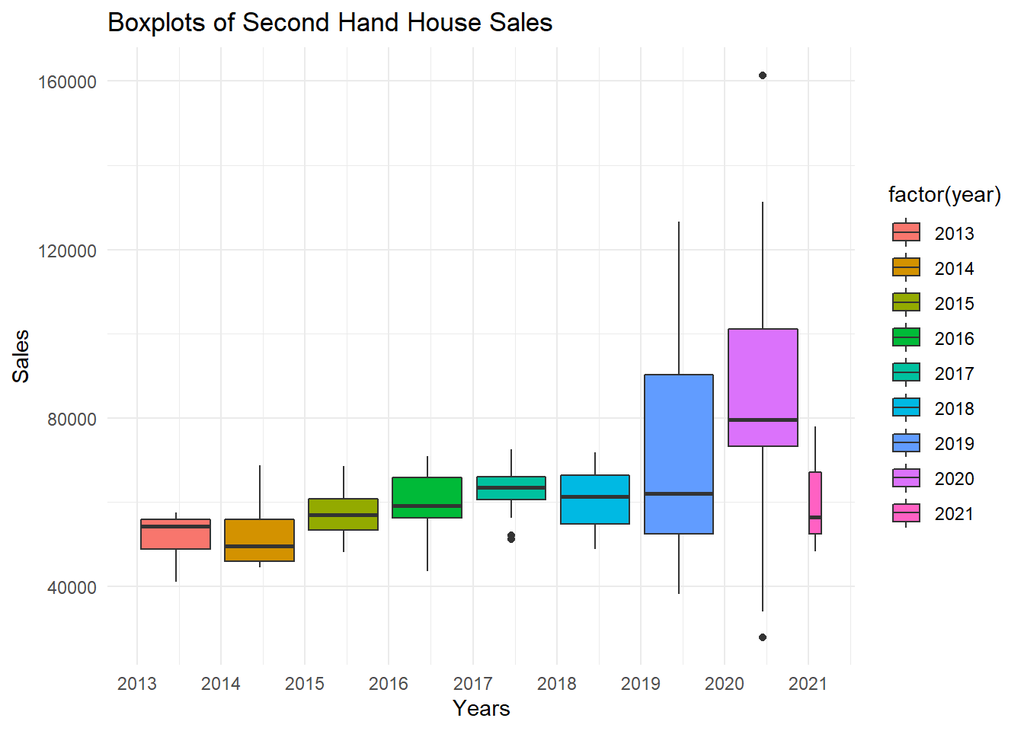

By analyzing boxplots, it is more clear that there is outliers in 2020 and besides them there is low sales in 2017 and drop in average second hand sales in 2018, It can be due to the economic crisis in 2018. Morever, there is a slight trend in the average of second hand house sales year by year.

## Second Hand House Sales Statistics by Year

If data is observed year by year, the sales between 2013 and 2018 seems to have normal distribution and stationary. However after the 2018 the variance of sales is increasing.

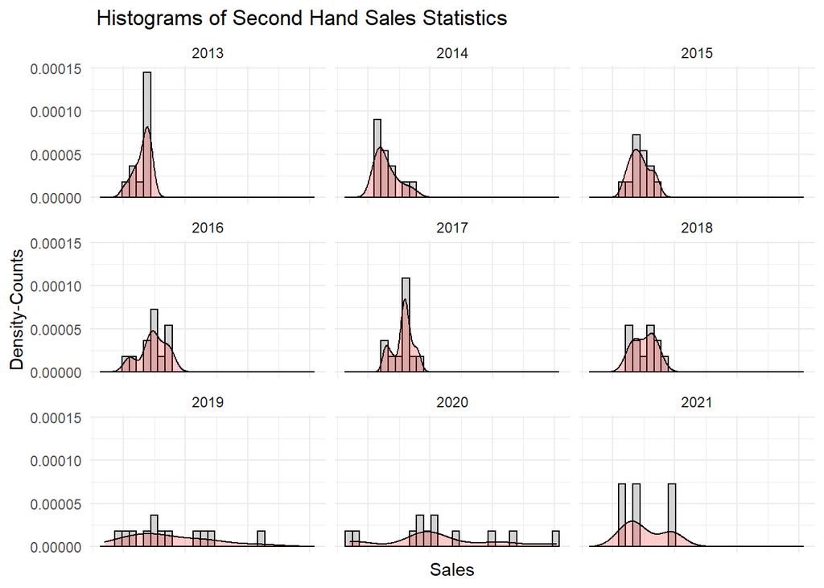

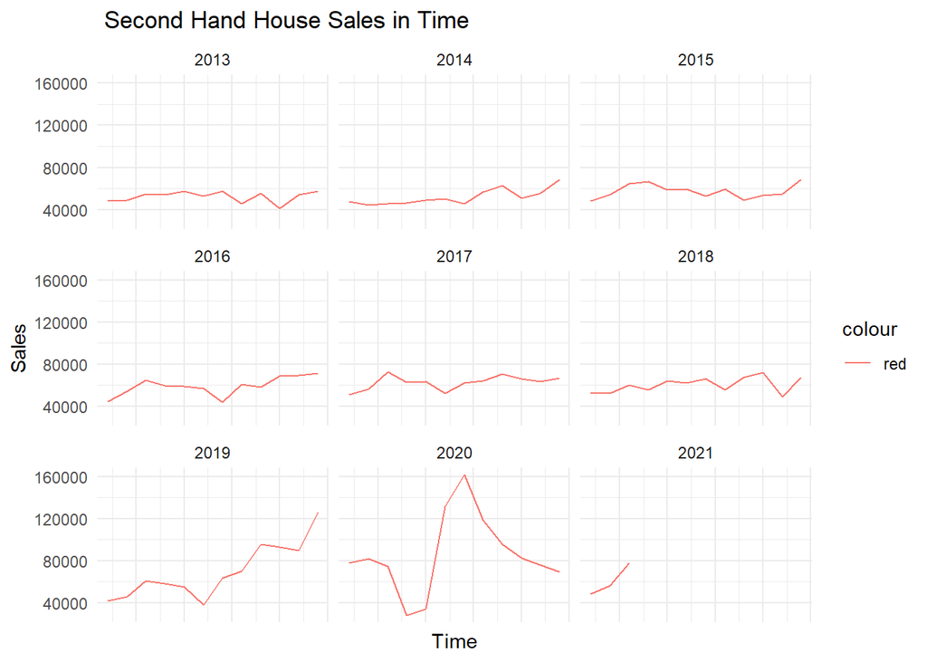

# Construct a Time Series Regression Model

First of all, the data saved as a timer series data since the data consist of yearly period by twelve months.

The sales has increasing variance , logarithms of sales taken and plotted to get more stable data

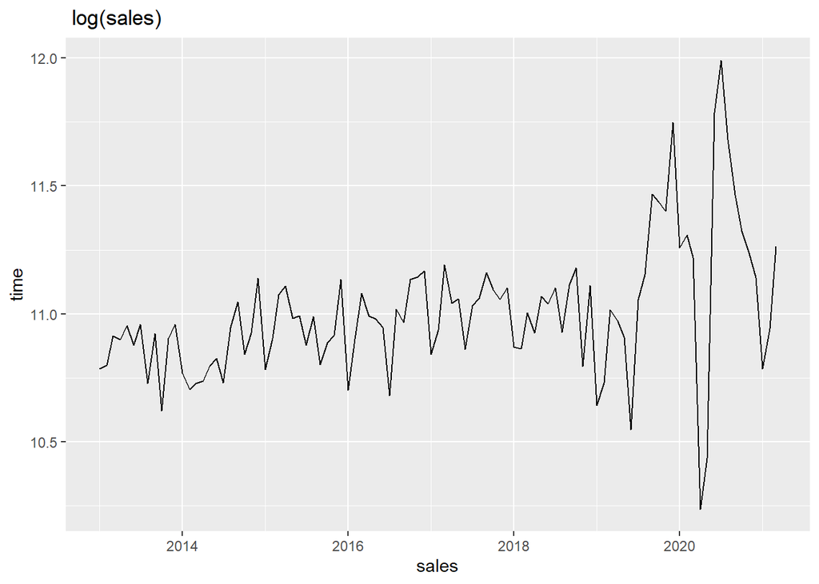

It seems more stable, therefore the model continued with the logartihms of sales and in the end it will be trasformed.

## Check Aouto Correlation

It is possible to data has aoutocorrealation and seasonality to get more accurate model, it is checked.

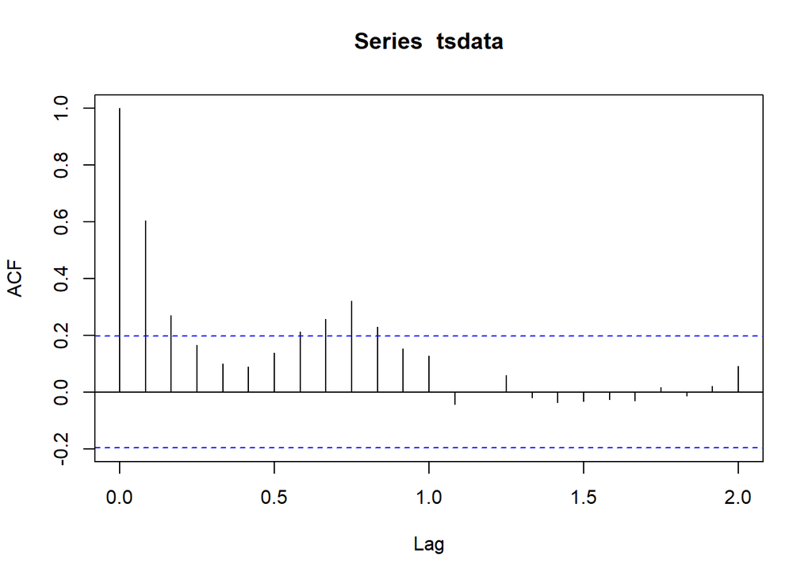

There is a stong positive correalation in lag 1 and lag 9, therefore firstly I add my model the observations before one month ago and nine month ago, and analyze the effects on the sales for the current values.

** Create the lag1 variable and construct a model **

```
##
## Call:
## lm(formula = log_sales ~ lag1, data = sales[-1])
##
## Residuals:
##      Min       1Q   Median       3Q      Max
## -0.88242 -0.09960  0.00925  0.10250  1.07562
##
## Coefficients:
##             Estimate Std. Error t value Pr(>|t|)
## (Intercept)  5.24994    0.95902   5.474 3.51e-07 ***
## lag1         0.52320    0.08715   6.003 3.44e-08 ***
## ---
## Signif. codes:  0 '***' 0.001 '**' 0.01 '*' 0.05 '.' 0.1 ' ' 1
##
## Residual standard error: 0.2269 on 96 degrees of freedom
## Multiple R-squared:  0.2729, Adjusted R-squared:  0.2654
## F-statistic: 36.04 on 1 and 96 DF,  p-value: 3.436e-08
```

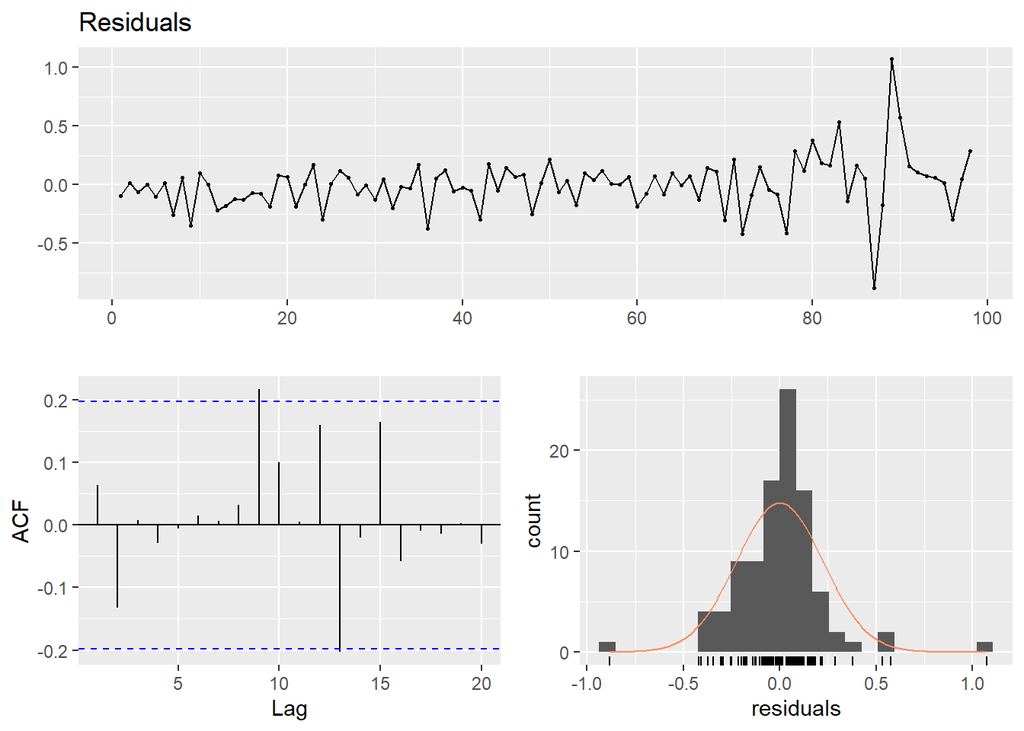

```
##
##  Breusch-Godfrey test for serial correlation of order up to 10
##
## data:  Residuals
## LM test = 10.341, df = 10, p-value = 0.4111
```

lag1 is seems to be a significant variable for the model and the residuals seems to be near normal distribution but have increasing variance and no high auotocorrelation between themselves, I will add the lag1 variable and study on the increasing varibale in next steps.

```
##
## Call:
## lm(formula = log_sales ~ lag1 + lag9, data = sales[-9])
##
## Residuals:
##      Min       1Q   Median       3Q      Max
## -0.79157 -0.14726 -0.00302  0.11053  0.93602
##
## Coefficients:
##              Estimate Std. Error t value Pr(>|t|)
## (Intercept) 10.503401   0.253563  41.423   <2e-16 ***
## lag1         0.034246   0.024989   1.370    0.174
## lag9         0.012619   0.009383   1.345    0.182
## ---
## Signif. codes:  0 '***' 0.001 '**' 0.01 '*' 0.05 '.' 0.1 ' ' 1
##
## Residual standard error: 0.2604 on 95 degrees of freedom
## Multiple R-squared:  0.05864,    Adjusted R-squared:  0.03882
## F-statistic: 2.959 on 2 and 95 DF,  p-value: 0.05669
```

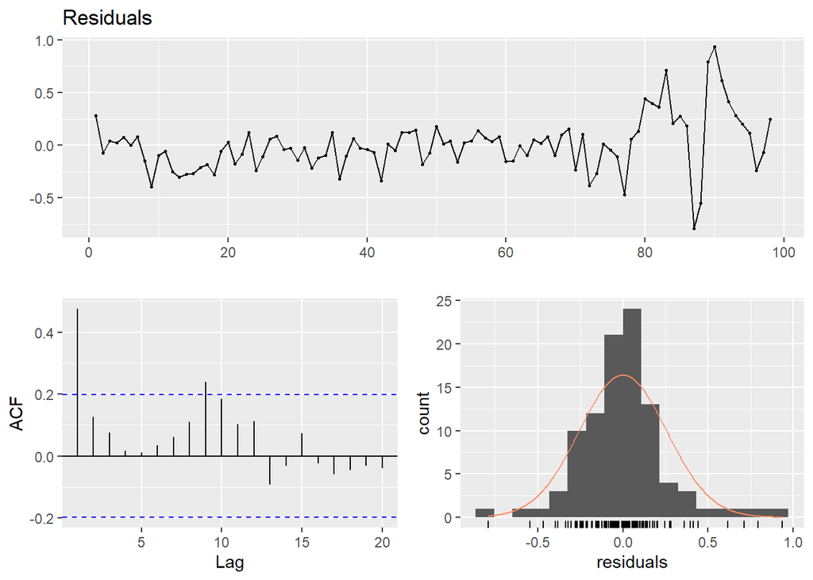

```
##
##  Breusch-Godfrey test for serial correlation of order up to 10
##
## data:  Residuals
## LM test = 31.685, df = 10, p-value = 0.0004519
```

By adding lag9 variable the R-Saquared of teh model is significantly decreased and the moel seems to insignificant, therefore I removed the lag9 variable and contiune with the lag1 variable.

There is the model by constructing with using lag1 variable and the plot of real variables.

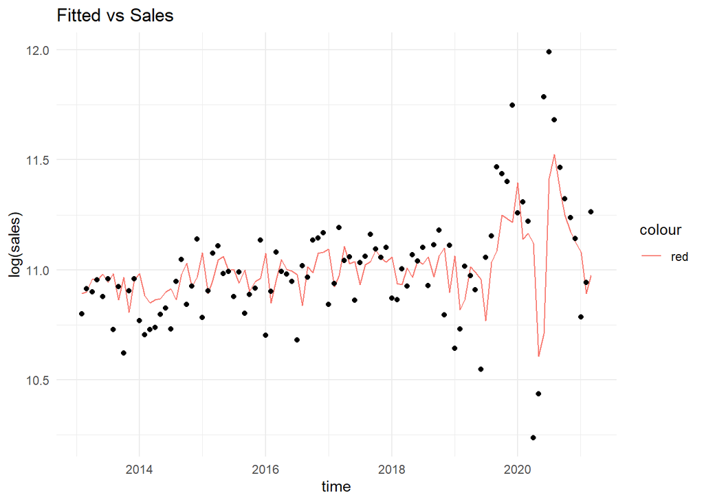

the model seems not well covered variance of sales by considering low adjusted-R squared of model and the graph above.

## Add Trend

In the box plot of data, it was observed that there is a slight trend in the data, therefore I added the trend component to the model.

```
##
## Call:
## lm(formula = log_sales ~ trend + lag1, data = sales)
##
## Residuals:
##      Min       1Q   Median       3Q      Max
## -0.94810 -0.11007  0.01365  0.10978  0.91679
##
## Coefficients:
##              Estimate Std. Error t value Pr(>|t|)
## (Intercept) 6.3710978  1.0118162   6.297 9.38e-09 ***
## trend       0.0024104  0.0008702   2.770  0.00674 **
## lag1        0.4104351  0.0935923   4.385 2.99e-05 ***
## ---
## Signif. codes:  0 '***' 0.001 '**' 0.01 '*' 0.05 '.' 0.1 ' ' 1
##
## Residual standard error: 0.2194 on 95 degrees of freedom
## Multiple R-squared:  0.3273, Adjusted R-squared:  0.3131
## F-statistic: 23.11 on 2 and 95 DF,  p-value: 6.645e-09
```

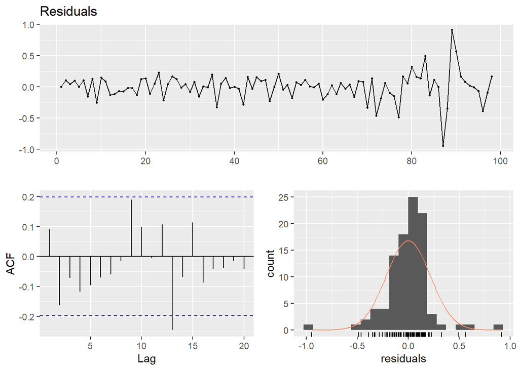

```
##
##  Breusch-Godfrey test for serial correlation of order up to 10
##
## data:  Residuals
## LM test = 12.063, df = 10, p-value = 0.2808
```

The trend component increase the autocorrelation between residuals and disturb normal distribution, howeever, I will add to my model since it increase adjusted R-squared value significantly and it seems to significant for my model.

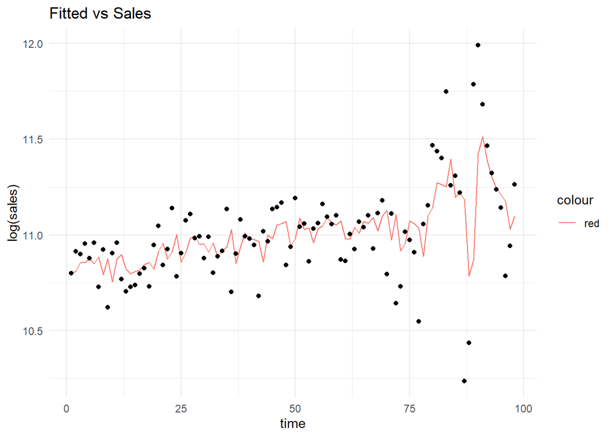

## Add Seasonality Component

By loooking the graph of second hand house sales during time, it is observed that increase in the beginings of year and drops the middles of years. Therefore, I add the seasonality component as a factor of months.

```
##
## Call:
## lm(formula = log_sales ~ lag1 + trend + as.factor(month), data = sales)
##
## Residuals:
##      Min       1Q   Median       3Q      Max
## -0.80787 -0.07017  0.02327  0.07875  0.93293
##
## Coefficients:
##                     Estimate Std. Error t value Pr(>|t|)
## (Intercept)        5.3519671  1.0508500   5.093 2.13e-06 ***
## lag1               0.4794989  0.0954196   5.025 2.80e-06 ***
## trend              0.0021301  0.0008152   2.613 0.010633 *
## as.factor(month)2  0.2513368  0.1038211   2.421 0.017638 *
## as.factor(month)3  0.3702227  0.1019286   3.632 0.000483 ***
## as.factor(month)4  0.1284096  0.1022376   1.256 0.212601
## as.factor(month)5  0.2395145  0.1052791   2.275 0.025450 *
## as.factor(month)6  0.3071527  0.1045032   2.939 0.004249 **
## as.factor(month)7  0.3319968  0.1028681   3.227 0.001782 **
## as.factor(month)8  0.3073018  0.1019921   3.013 0.003418 **
## as.factor(month)9  0.3548837  0.1019051   3.482 0.000791 ***
## as.factor(month)10 0.2733213  0.1015058   2.693 0.008555 **
## as.factor(month)11 0.2792575  0.1019382   2.739 0.007514 **
## as.factor(month)12 0.4263832  0.1021709   4.173 7.29e-05 ***
## ---
## Signif. codes:  0 '***' 0.001 '**' 0.01 '*' 0.05 '.' 0.1 ' ' 1
##
## Residual standard error: 0.2027 on 84 degrees of freedom
## Multiple R-squared:  0.4926, Adjusted R-squared:  0.4141
## F-statistic: 6.274 on 13 and 84 DF,  p-value: 4.341e-08
```

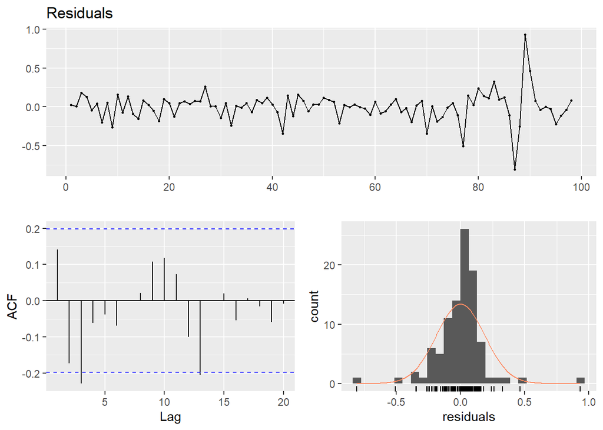

```
##
##  Breusch-Godfrey test for serial correlation of order up to 17
##
## data:  Residuals
## LM test = 31.102, df = 17, p-value = 0.01941
```

Adding months as a factor variable clearly improved my model. The autocorrelation in month nine is obeserve as a significant variable in seasonality.

## Removing Outliers

I construct my model by removing outliers and check the results.

```
##
## Call:
## lm(formula = log_sales ~ trend + lag1 + as.factor(month), data = sales)
##
## Residuals:
##      Min       1Q   Median       3Q      Max
## -0.35952 -0.05822  0.02455  0.07618  0.25466
##
## Coefficients:
##                     Estimate Std. Error t value Pr(>|t|)
## (Intercept)        5.5580388  0.9524723   5.835 1.16e-07 ***
## trend              0.0017239  0.0005864   2.940 0.004320 **
## lag1               0.4630415  0.0865598   5.349 8.57e-07 ***
## as.factor(month)2  0.2433491  0.0682734   3.564 0.000626 ***
## as.factor(month)3  0.3638324  0.0658883   5.522 4.25e-07 ***
## as.factor(month)4  0.2346464  0.0668007   3.513 0.000741 ***
## as.factor(month)5  0.2658985  0.0676431   3.931 0.000182 ***
## as.factor(month)6  0.1649170  0.0674508   2.445 0.016740 *
## as.factor(month)7  0.2554952  0.0698013   3.660 0.000456 ***
## as.factor(month)8  0.2873058  0.0685413   4.192 7.24e-05 ***
## as.factor(month)9  0.3512054  0.0639408   5.493 4.79e-07 ***
## as.factor(month)10 0.2709478  0.0634222   4.272 5.42e-05 ***
## as.factor(month)11 0.2764139  0.0639989   4.319 4.57e-05 ***
## as.factor(month)12 0.3744365  0.0671348   5.577 3.39e-07 ***
## ---
## Signif. codes:  0 '***' 0.001 '**' 0.01 '*' 0.05 '.' 0.1 ' ' 1
##
## Residual standard error: 0.1264 on 78 degrees of freedom
## Multiple R-squared:  0.6175, Adjusted R-squared:  0.5538
## F-statistic: 9.687 on 13 and 78 DF,  p-value: 1.228e-11
```

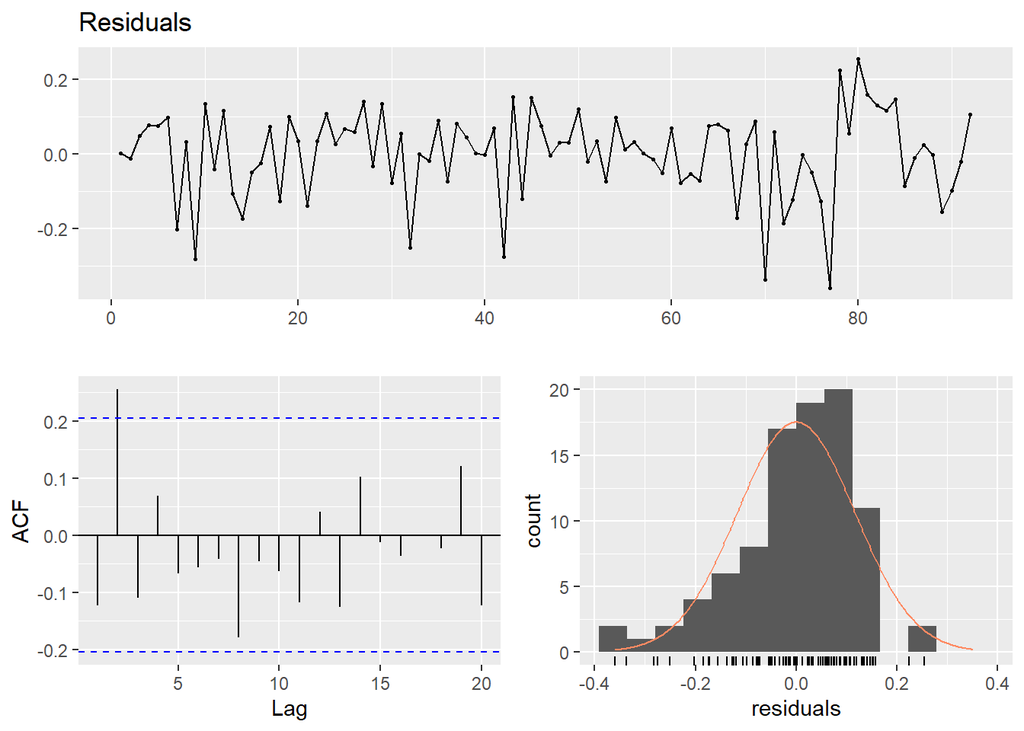

```
##
##  Breusch-Godfrey test for serial correlation of order up to 17
##
## data:  Residuals
## LM test = 17.161, df = 17, p-value = 0.4435
```

Removing outliers improved my model significantly and decrease the increasing variance in residuals.

# Improve Model by Adding External Variables

I will add my model related external ecnomics variables from [EVDS](https://evds2.tcmb.gov.tr/index.php?/evds/serieMarket) that can affect the second hand house sales in Turkey. The variables are USD exchange Rate, interest rate of Consumer Loan for Housing, and resluts of Survey in Turkey which reported probabilty of buying or building home(over the next 12 months).

## USD Exchange Rate

USD exchange rate is positively correlated with Second hand house sales. Turkish people use as a saving source the USD since turkish liras losing its value. It can be reason of the positive correlation.

```
##
## Call:
## lm(formula = log_sales ~ USD, data = sales)
##
## Residuals:
##      Min       1Q   Median       3Q      Max
## -0.54396 -0.10839  0.02703  0.08682  0.38067
##
## Coefficients:
##             Estimate Std. Error t value Pr(>|t|)
## (Intercept) 10.78118    0.04235 254.571  < 2e-16 ***
## USD          0.05344    0.01012   5.283 8.78e-07 ***
## ---
## Signif. codes:  0 '***' 0.001 '**' 0.01 '*' 0.05 '.' 0.1 ' ' 1
##
## Residual standard error: 0.1662 on 90 degrees of freedom
## Multiple R-squared:  0.2367, Adjusted R-squared:  0.2282
## F-statistic: 27.91 on 1 and 90 DF,  p-value: 8.783e-07
```

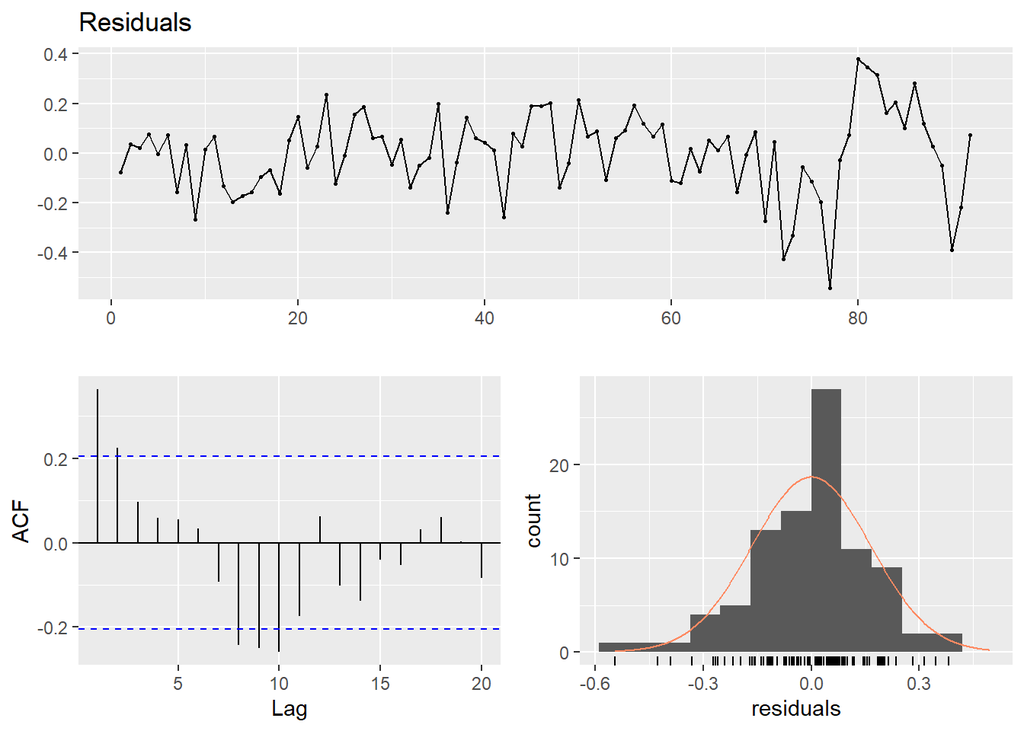

```
##
##  Breusch-Godfrey test for serial correlation of order up to 10
##
## data:  Residuals
## LM test = 21.456, df = 10, p-value = 0.01813
```

```
##
## Call:
## lm(formula = log_sales ~ trend + lag1 + as.factor(month) + USD,
##     data = sales)
##
## Residuals:
##      Min       1Q   Median       3Q      Max
## -0.34983 -0.07742  0.02187  0.07637  0.24852
##
## Coefficients:
##                     Estimate Std. Error t value Pr(>|t|)
## (Intercept)         5.516861   0.952316   5.793 1.43e-07 ***
## trend               0.003356   0.001629   2.060 0.042805 *
## lag1                0.469365   0.086676   5.415 6.73e-07 ***
## as.factor(month)2   0.245247   0.068230   3.594 0.000571 ***
## as.factor(month)3   0.367455   0.065911   5.575 3.51e-07 ***
## as.factor(month)4   0.233708   0.066741   3.502 0.000773 ***
## as.factor(month)5   0.266259   0.067578   3.940 0.000178 ***
## as.factor(month)6   0.163895   0.067392   2.432 0.017339 *
## as.factor(month)7   0.253796   0.069751   3.639 0.000494 ***
## as.factor(month)8   0.288052   0.068478   4.206 6.94e-05 ***
## as.factor(month)9   0.356779   0.064089   5.567 3.63e-07 ***
## as.factor(month)10  0.275172   0.063482   4.335 4.37e-05 ***
## as.factor(month)11  0.279168   0.063988   4.363 3.94e-05 ***
## as.factor(month)12  0.376768   0.067105   5.615 2.99e-07 ***
## USD                -0.027909   0.025999  -1.073 0.286407
## ---
## Signif. codes:  0 '***' 0.001 '**' 0.01 '*' 0.05 '.' 0.1 ' ' 1
##
## Residual standard error: 0.1263 on 77 degrees of freedom
## Multiple R-squared:  0.6232, Adjusted R-squared:  0.5546
## F-statistic: 9.095 on 14 and 77 DF,  p-value: 2.347e-11
```

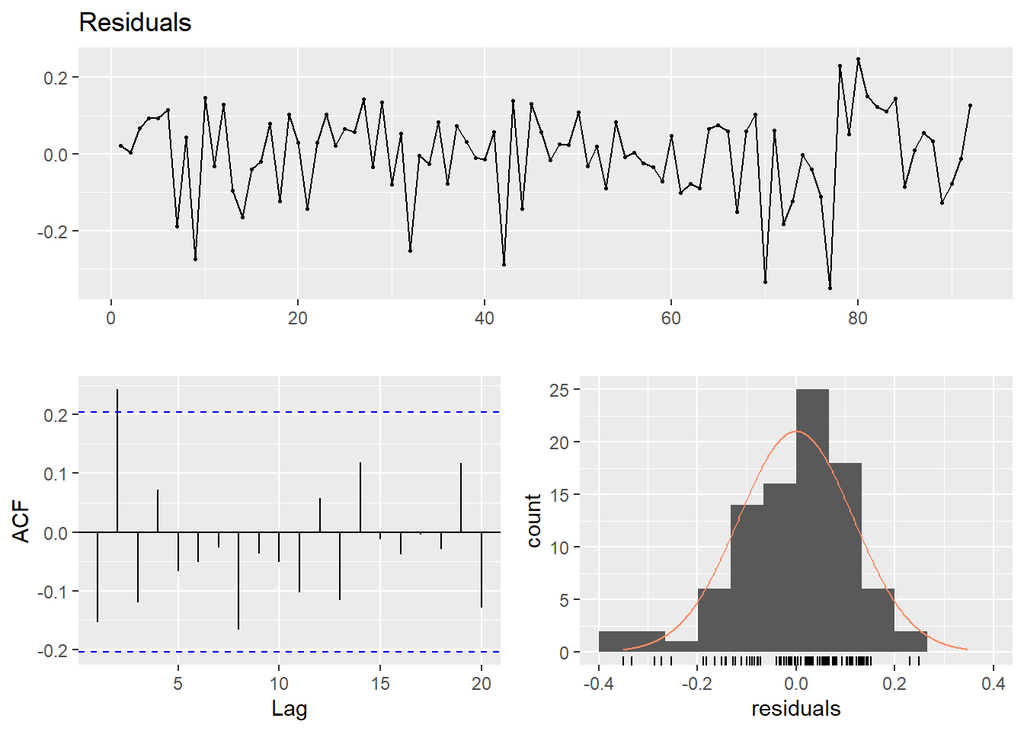

```
##
##  Breusch-Godfrey test for serial correlation of order up to 18
##
## data:  Residuals
## LM test = 18.366, df = 18, p-value = 0.4318
```

In the first model I add only USD exchange rate and I see it is significant but not sufficient for the predicted house sales.

Secondly, If we examine the results with time series components even if USD exchange rates highly positive correlated with the second hand house sales, it is insignificant and has negative coefficient in the model. However, I will keep USD exchange rate in my model to analyze with other external variables.

## Interest Rate of Consumer Loan for Housing

```
##
## Call:
## lm(formula = log_sales ~ trend + lag1 + as.factor(month) + USD +
##     ConsumerLoan, data = sales)
##
## Residuals:
##       Min        1Q    Median        3Q       Max
## -0.311459 -0.053839  0.002931  0.078642  0.280158
##
## Coefficients:
##                     Estimate Std. Error t value Pr(>|t|)
## (Intercept)         7.982980   1.089798   7.325 2.13e-10 ***
## trend               0.003785   0.001506   2.513 0.014107 *
## lag1                0.257140   0.097326   2.642 0.010001 *
## as.factor(month)2   0.166974   0.066157   2.524 0.013693 *
## as.factor(month)3   0.290205   0.064043   4.531 2.14e-05 ***
## as.factor(month)4   0.201784   0.062096   3.250 0.001723 **
## as.factor(month)5   0.224065   0.063274   3.541 0.000684 ***
## as.factor(month)6   0.122977   0.063048   1.951 0.054799 .
## as.factor(month)7   0.200076   0.065826   3.039 0.003249 **
## as.factor(month)8   0.228738   0.065014   3.518 0.000737 ***
## as.factor(month)9   0.321012   0.059824   5.366 8.42e-07 ***
## as.factor(month)10  0.262070   0.058627   4.470 2.69e-05 ***
## as.factor(month)11  0.253379   0.059378   4.267 5.64e-05 ***
## as.factor(month)12  0.353674   0.062161   5.690 2.26e-07 ***
## USD                 0.004194   0.025400   0.165 0.869289
## ConsumerLoan       -0.016866   0.004415  -3.820 0.000271 ***
## ---
## Signif. codes:  0 '***' 0.001 '**' 0.01 '*' 0.05 '.' 0.1 ' ' 1
##
## Residual standard error: 0.1164 on 76 degrees of freedom
## Multiple R-squared:  0.6839, Adjusted R-squared:  0.6215
## F-statistic: 10.96 on 15 and 76 DF,  p-value: 1.646e-13
```

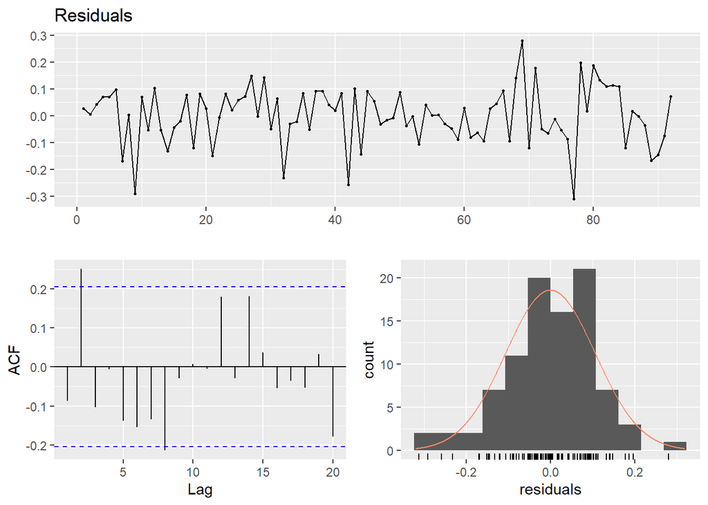

```
##
##  Breusch-Godfrey test for serial correlation of order up to 19
##
## data:  Residuals
## LM test = 25.937, df = 19, p-value = 0.132
```

## The Probability of buying or Building a Home

The Probability of buying or Building a Home is expected to positive corellation with Second hand house sales since it shows people’s tendency to buy house.

```
##
## Call:
## lm(formula = log_sales ~ trend + lag1 + as.factor(month) + USD +
##     ConsumerLoan + PrBuyingBuildingHome, data = sales)
##
## Residuals:
##      Min       1Q   Median       3Q      Max
## -0.32989 -0.05616  0.00419  0.07958  0.27281
##
## Coefficients:
##                       Estimate Std. Error t value Pr(>|t|)
## (Intercept)           8.366964   1.155525   7.241 3.28e-10 ***
## trend                 0.003005   0.001696   1.771 0.080577 .
## lag1                  0.233340   0.100197   2.329 0.022565 *
## as.factor(month)2     0.158208   0.066736   2.371 0.020327 *
## as.factor(month)3     0.288195   0.064074   4.498 2.46e-05 ***
## as.factor(month)4     0.207193   0.062332   3.324 0.001375 **
## as.factor(month)5     0.225179   0.063285   3.558 0.000652 ***
## as.factor(month)6     0.122481   0.063050   1.943 0.055818 .
## as.factor(month)7     0.196767   0.065910   2.985 0.003823 **
## as.factor(month)8     0.223524   0.065223   3.427 0.000994 ***
## as.factor(month)9     0.310497   0.060742   5.112 2.36e-06 ***
## as.factor(month)10    0.253949   0.059188   4.291 5.25e-05 ***
## as.factor(month)11    0.242463   0.060374   4.016 0.000139 ***
## as.factor(month)12    0.340405   0.063563   5.355 9.01e-07 ***
## USD                   0.016688   0.028309   0.590 0.557293
## ConsumerLoan         -0.019325   0.005055  -3.823 0.000270 ***
## PrBuyingBuildingHome -0.010807   0.010811  -1.000 0.320725
## ---
## Signif. codes:  0 '***' 0.001 '**' 0.01 '*' 0.05 '.' 0.1 ' ' 1
##
## Residual standard error: 0.1164 on 75 degrees of freedom
## Multiple R-squared:  0.688,  Adjusted R-squared:  0.6215
## F-statistic: 10.34 on 16 and 75 DF,  p-value: 3.551e-13
```

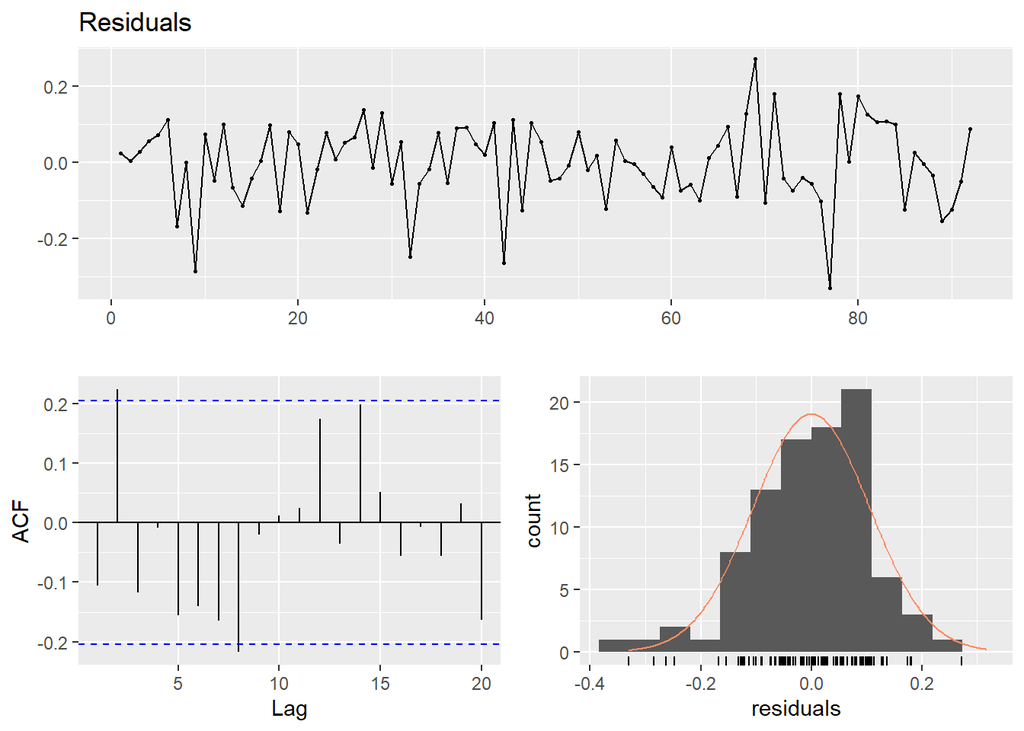

```
##
##  Breusch-Godfrey test for serial correlation of order up to 20
##
## data:  Residuals
## LM test = 30.247, df = 20, p-value = 0.06595
```

Results of The Probability of buying or Building a Home does not improved adjusted R-squared of my model.

## Final Shape of the Model

In the end, USD exchange rate and Probabilty of buyingv or uilding home is insignificant in my model, therefore I will extract both of them from my model to get more clean model, and my model has the final shape. However, its adjusted R-squared values is not sufficient as I expected. It is can be improved by analyzing deeply the reasons of variations in the data.

```
##
## Call:
## lm(formula = log_sales ~ trend + lag1 + as.factor(month) + ConsumerLoan,
##     data = sales)
##
## Residuals:
##       Min        1Q    Median        3Q       Max
## -0.310711 -0.052746  0.004191  0.079163  0.279993
##
## Coefficients:
##                      Estimate Std. Error t value Pr(>|t|)
## (Intercept)         7.9421967  1.0547138   7.530 8.12e-11 ***
## trend               0.0039970  0.0007801   5.124 2.16e-06 ***
## lag1                0.2610221  0.0938459   2.781 0.006802 **
## as.factor(month)2   0.1683471  0.0652163   2.581 0.011740 *
## as.factor(month)3   0.2917947  0.0629135   4.638 1.41e-05 ***
## as.factor(month)4   0.2021149  0.0616708   3.277 0.001574 **
## as.factor(month)5   0.2247170  0.0627511   3.581 0.000597 ***
## as.factor(month)6   0.1234256  0.0625902   1.972 0.052205 .
## as.factor(month)7   0.2006173  0.0653281   3.071 0.002948 **
## as.factor(month)8   0.2296863  0.0643497   3.569 0.000620 ***
## as.factor(month)9   0.3222690  0.0589610   5.466 5.48e-07 ***
## as.factor(month)10  0.2628231  0.0580796   4.525 2.16e-05 ***
## as.factor(month)11  0.2541161  0.0588348   4.319 4.62e-05 ***
## as.factor(month)12  0.3543163  0.0616461   5.748 1.73e-07 ***
## ConsumerLoan       -0.0166246  0.0041402  -4.015 0.000137 ***
## ---
## Signif. codes:  0 '***' 0.001 '**' 0.01 '*' 0.05 '.' 0.1 ' ' 1
##
## Residual standard error: 0.1157 on 77 degrees of freedom
## Multiple R-squared:  0.6837, Adjusted R-squared:  0.6262
## F-statistic: 11.89 on 14 and 77 DF,  p-value: 4.699e-14
```

There is a graph of fitted values of my model and the real values of second hand house sales.

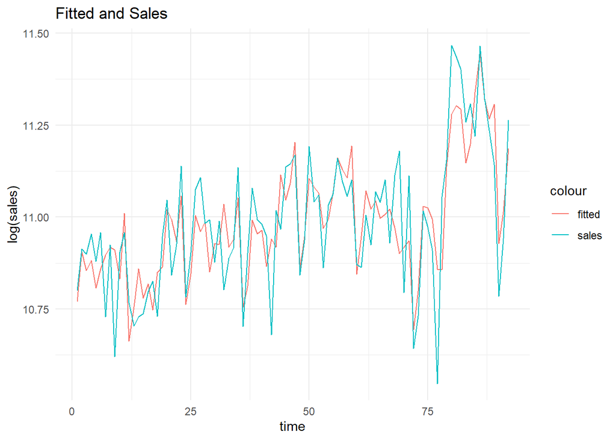

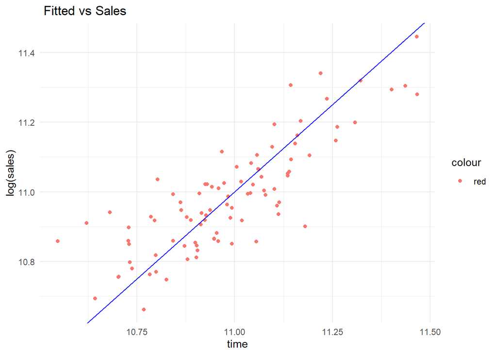

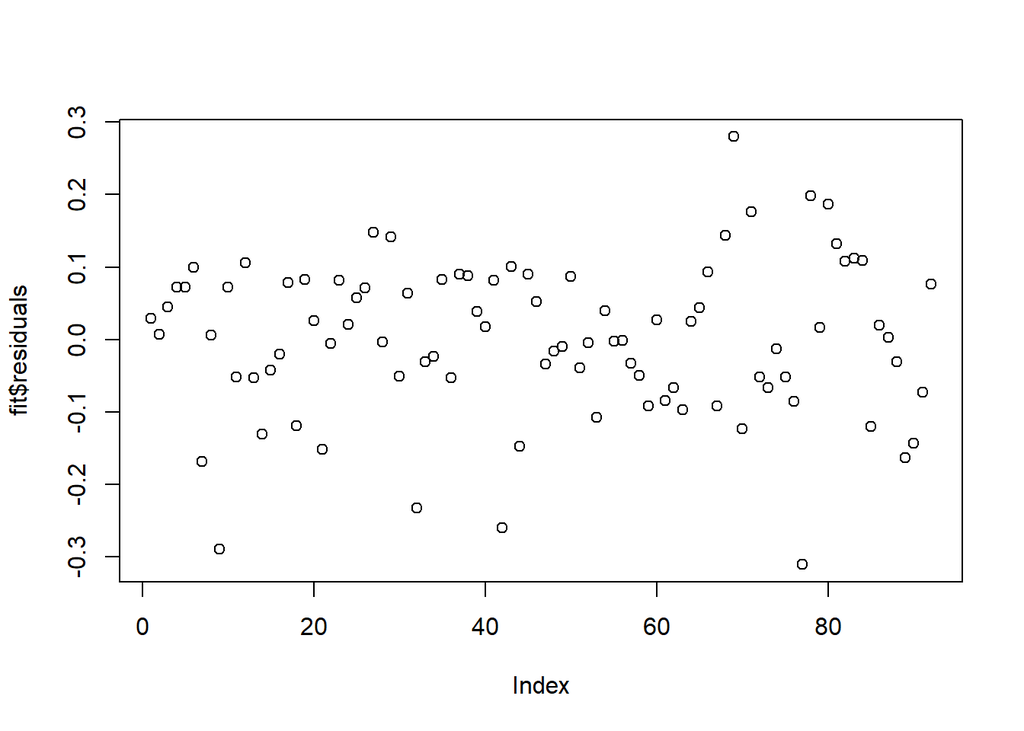

In the end, my model is insufficient for explain variance in the data. Expecially in lower values since there is more deviations observed in “Fitted vs Sales”, besides even if my residuals have nearly zero mean, they have high variance.

# Prediction

**MY PREDICTION FOR NEXT MONTH IS**

```
##        1
## 96748.78
```

There is a predictions and actual values of the second hand house sales in Turkey based on my model. It is expected an increase.

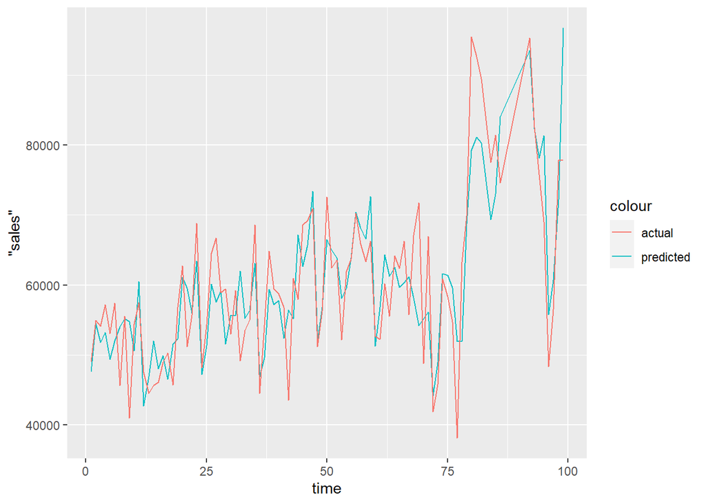

# Conclusion

# References

[the Central Bank of the Republic of Turkey’s Electronic Data Delivery System](https://evds2.tcmb.gov.tr)

[PS4](https://moodle.boun.edu.tr/pluginfile.php/788893/mod_resource/content/1/time_series_regression.R)

# RMD